# Gold Futures Price Prediction Using ARIMA

My Name

2024-08-21

# Introduction

This report analyses the future prices of gold futures using an ARIMA model. The data is sourced from Yahoo Finance, covering the period from Jan 1st, 2010, to the present.

## About the Source Dataset

We begin by collecting historical gold futures data from Yahoo Finance. The data spans from Jan 1st, 2010 to present. The data includes daily prices, but we are primarily interested in the adjusted close prices, which account for dividends and stock splits. Any missing values in the dataset are filled using linear interpolation to ensure the continuity of time series. The data is then converted into a time series object for further analysis.

```r
#Fetching historical Gold Futures data from Yahoo Finance; assigned to data frame `GC=F`
getSymbols("GC=F",src="yahoo",from="2010-01-01",to=Sys.Date(),auto.assign = TRUE)
```

```
## [1] "GC=F"
```

```r
#Extracting Adjusted Prices in form of 'GC=F.Adjusted' col from GC-F
gold_prices <- `GC=F`[,"GC=F.Adjusted"]

#To fill in any missing data in the source dataset from yahoo Finance
gold_prices <-  na.approx(gold_prices)

#Renaming col for easier reference
colnames(gold_prices) <- "Adjusted"

#converting gold_prices to a time Series object for analysis
gold_ts <- ts(gold_prices, start=c(year(index(gold_prices)[1]), month(index(gold_prices)[1])), frequency = 365)

#Display first few rows of data
head(gold_prices)
```

```
##            Adjusted
## 2010-01-04   1117.7
## 2010-01-05   1118.1
## 2010-01-06   1135.9
## 2010-01-07   1133.1
## 2010-01-08   1138.2
## 2010-01-11   1150.7
```

## The (Exploratory)Data Analysis conducted

To understand the trends and patterns in gold prices, we plot the adjusted gold prices over the entire period. This visualization helps us identify any trends, seasonality, or other patterns that might influence the model.

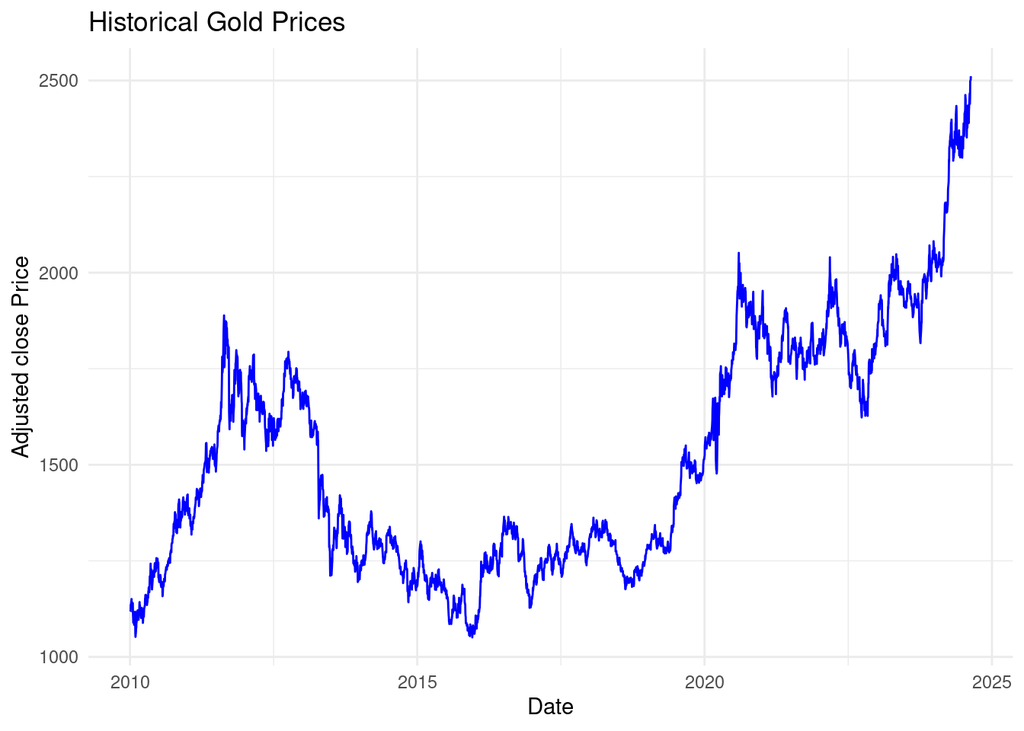

```r
# Plotting Adjusted close prices over time
ggplot(data=as.data.frame(gold_ts), aes(x=index(gold_prices),y=Adjusted))+
  geom_line(color="blue") +
  labs(title="Historical Gold Prices", x ="Date", y="Adjusted close Price")+theme_minimal()
```

## More on the Analysis method selected, the ARIMA model

To forecast future gold prices, we use the ARIMA(AutoRegressive Integrated Moving Average) model. ARIMA is a popular statistical method for time series forecasting that takes into account past values(auto-regression), differences between values to make the series stationary(integration), and past errs(moving avg).

```r
#Fitting an ARIMA model to the time series datahttps://8164986952ee4ace926d3eb531d0ecf3.app.posit.cloud/graphics/cfe1ee0a-4df5-40c3-a82d-1857371732e4.png
fit <- auto.arima(gold_ts)
summary(fit)
```

```
## Series: gold_ts
## ARIMA(0,1,1) with drift
##
## Coefficients:
##           ma1   drift
##       -0.0319  0.3784
## s.e.   0.0166  0.2524
##
## sigma^2 = 250.4:  log likelihood = -15395.78
## AIC=30797.56   AICc=30797.56   BIC=30816.19
##
## Training set error measures:
##                        ME     RMSE      MAE          MPE      MAPE     MASE
## Training set 0.0002282804 15.81808 10.86746 -0.009279138 0.7092996 0.050462
##                      ACF1
## Training set 0.0001671867
```

## Actual forecast

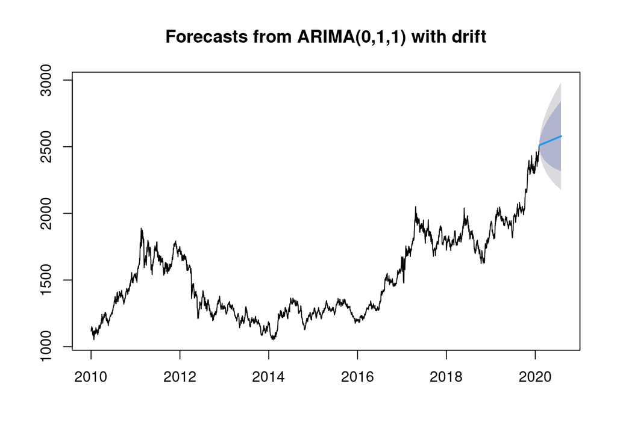

```r
#Forecasting the next 180 days(6 mo) and plot them
forecasted_values <- forecast(fit, h=180)
plot(forecasted_values)
```

## Evaluating the accuracy of the forecast

To evaluate the accuracy of our model, we analyse the residuals, which are the differences between the predicted and actual gold values. Ideally, residuals should be randomly distributed with no clear pattern(s), indicating a good fit. We also perform a statistical test to check if any patterns remain in the residuals.

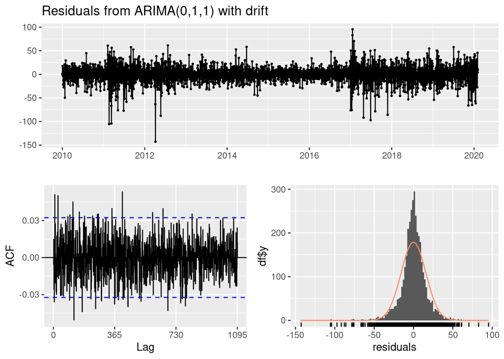

```
##
##  Ljung-Box test
##
## data:  Residuals from ARIMA(0,1,1) with drift
## Q* = 808.16, df = 729, p-value = 0.0217
##
## Model df: 1.   Total lags used: 730
```

```r
#Checking residuals to evaluate the degree of fit of the project
checkresiduals(fit)
```

# Conclusion

The ARIMA model provides a forecast for gold futures prices over the next six months. The confidence intervals suggest a reasonable level of uncertainty, indicating potential variablility in future prices. This analysis is based on historical data and does not account for sudden market changes or unforseen events. *Note: author takes no responsibility for losses incurred via decisions made using provided analysis or any other segments of this project.*